# Banu Boopalan: Module1 Homework

```r
#Top 50 records by revenue
revenuetop50 = inc %>% arrange(desc(Revenue)) %>% head(50)
#revenuetop50
revenuetop50$Revenue1 = sapply(revenuetop50$Revenue, function(x) paste(round((x / 1e9), 1), " Billion"))
revenuetop50 %>% kable() %>% kable_styling()
```

| Rank | Name | Growth_Rate | Revenue | Industry | Employees | City | State | Revenue1 |
| --- | --- | --- | --- | --- | --- | --- | --- | --- |
| 4788 | CDW | 0.41 | 1.010e+10 | Computer Hardware | 6800 | Vernon Hills | IL | 10.1 Billion |
| 3853 | ABC Supply | 0.73 | 4.700e+09 | Construction | 6549 | Beloit | WI | 4.7 Billion |
| 4936 | Coty | 0.36 | 4.600e+09 | Consumer Products & Services | 10000 | New York | NY | 4.6 Billion |
| 4997 | Dot Foods | 0.34 | 4.500e+09 | Food & Beverage | 3919 | Mt. Sterling | IL | 4.5 Billion |
| 4716 | Westcon Group | 0.44 | 3.800e+09 | IT Services | 3000 | Tarrytown | NY | 3.8 Billion |
| 4246 | American Tire Distributors | 0.59 | 3.500e+09 | Consumer Products & Services | 3341 | Huntersville | NC | 3.5 Billion |
| 4052 | Kum & Go | 0.65 | 2.800e+09 | Retail | 4589 | West Des Moines | IA | 2.8 Billion |
| 4802 | Boise Cascade | 0.41 | 2.800e+09 | Construction | 4470 | Boise | ID | 2.8 Billion |
| 1397 | EnvisionRxOptions | 2.88 | 2.700e+09 | Health | 625 | Twinsburg | OH | 2.7 Billion |
| 2522 | DLA Piper | 1.41 | 2.400e+09 | Business Products & Services | 4036 | Chicago | IL | 2.4 Billion |
| 4629 | Prime Therapeutics | 0.47 | 2.000e+09 | Health | 2549 | Eagan | MN | 2 Billion |
| 4 | Bridger | 233.08 | 1.900e+09 | Energy | 50 | Addison | TX | 1.9 Billion |
| 1843 | Sun Coast Resources | 2.08 | 1.900e+09 | Energy | 1640 | Houston | TX | 1.9 Billion |
| 3844 | Atlas Oil Company | 0.74 | 1.900e+09 | Logistics & Transportation | 374 | Taylor | MI | 1.9 Billion |
| 4961 | Kirkland & Ellis | 0.36 | 1.900e+09 | Business Products & Services | 1517 | Chicago | IL | 1.9 Billion |
| 1488 | Sprouts Farmers Market | 2.68 | 1.800e+09 | Consumer Products & Services | 13200 | Phoenix | AZ | 1.8 Billion |
| 4689 | Global Brass and Copper Holdings | 0.45 | 1.700e+09 | Manufacturing | 1986 | Schaumburg | IL | 1.7 Billion |
| 3463 | Hogan Lovells | 0.89 | 1.600e+09 | Business Products & Services | 2280 | Washington | DC | 1.6 Billion |
| 2145 | AdvancePierre Foods | 1.73 | 1.500e+09 | Food & Beverage | 4000 | Cincinnati | OH | 1.5 Billion |
| 3650 | Genco | 0.82 | 1.500e+09 | Logistics & Transportation | 10800 | Pittsburgh | PA | 1.5 Billion |
| 960 | Advanced Disposal | 4.51 | 1.400e+09 | Environmental Services | 5347 | Ponte Vedra | FL | 1.4 Billion |
| 2236 | Total Quality Logistics | 1.65 | 1.400e+09 | Logistics & Transportation | 2116 | Cincinnati | OH | 1.4 Billion |
| 2496 | Carahsoft Technology | 1.42 | 1.400e+09 | Government Services | 365 | Reston | VA | 1.4 Billion |
| 3414 | Restoration Hardware | 0.91 | 1.200e+09 | Retail | 2900 | Corte Madera | CA | 1.2 Billion |
| 1908 | Diplomat Specialty Pharmacy | 1.99 | 1.100e+09 | Health | 761 | Flint | MI | 1.1 Billion |
| 3734 | KSS | 0.78 | 1.000e+09 | Manufacturing | 8500 | Sterling Heights | MI | 1 Billion |
| 3425 | Blackhawk Network Holdings | 0.90 | 9.591e+08 | Financial Services | 725 | Pleasanton | CA | 1 Billion |
| 1996 | Ambit Energy | 1.88 | 9.303e+08 | Energy | 492 | Dallas | TX | 0.9 Billion |
| 4532 | GoDaddy.com | 0.49 | 9.109e+08 | IT Services | 3369 | Scottsdale | AZ | 0.9 Billion |
| 2958 | ImmixGroup | 1.15 | 8.836e+08 | IT Services | 252 | McLean | VA | 0.9 Billion |
| 4793 | LORD Corporation | 0.41 | 8.615e+08 | Manufacturing | 2959 | Cary | NC | 0.9 Billion |
| 3163 | Quinn Emanuel | 1.03 | 8.525e+08 | Business Products & Services | 697 | Los Angeles | CA | 0.9 Billion |
| 2961 | Genesis-ATC | 1.15 | 8.462e+08 | Telecommunications | 347 | San Antonio | TX | 0.8 Billion |
| 1284 | Hearthside Food Solutions | 3.17 | 8.396e+08 | Food & Beverage | 5000 | Downers Grove | IL | 0.8 Billion |
| 1480 | Coyote Logistics | 2.70 | 7.864e+08 | Logistics & Transportation | 1219 | Chicago | IL | 0.8 Billion |
| 4765 | Squire Sanders | 0.42 | 7.745e+08 | Business Products & Services | 1257 | Cleveland | OH | 0.8 Billion |
| 3921 | Granite Telecommunications | 0.70 | 7.362e+08 | Telecommunications | 1000 | Quincy | MA | 0.7 Billion |
| 4854 | Arnold & Porter | 0.40 | 7.310e+08 | Business Products & Services | 748 | Washington | DC | 0.7 Billion |
| 1869 | Universal Services of America | 2.04 | 7.181e+08 | Security | 20000 | Santa Ana | CA | 0.7 Billion |
| 2274 | Liberty Power | 1.61 | 7.108e+08 | Energy | 277 | Fort Lauderdale | FL | 0.7 Billion |
| 4427 | Sunshine Minting | 0.53 | 7.061e+08 | Manufacturing | 280 | Coeur D’ Alene | ID | 0.7 Billion |
| 4459 | Belcan | 0.52 | 6.887e+08 | Engineering | 10000 | Cincinnati | OH | 0.7 Billion |
| 2806 | Goodman Networks | 1.23 | 6.509e+08 | Telecommunications | 1693 | Plano | TX | 0.7 Billion |
| 4009 | Schumacher Group | 0.67 | 6.130e+08 | Health | 1945 | Lafayette | LA | 0.6 Billion |
| 4815 | Perkins Coie | 0.40 | 6.080e+08 | Business Products & Services | 823 | Seattle | WA | 0.6 Billion |
| 1768 | The Cellular Connection | 2.17 | 6.065e+08 | Telecommunications | 1428 | Marion | IN | 0.6 Billion |
| 2537 | Wayfair.com | 1.40 | 6.020e+08 | Retail | 1300 | Boston | MA | 0.6 Billion |
| 4577 | Sutherland Global Services | 0.48 | 5.976e+08 | Business Products & Services | 32000 | Pittsford | NY | 0.6 Billion |
| 4093 | Advanced BioEnergy | 0.64 | 5.848e+08 | Energy | 75 | Bloomington | MN | 0.6 Billion |
| 4857 | AVI-SPL | 0.39 | 5.807e+08 | Business Products & Services | 1800 | Tampa | FL | 0.6 Billion |

```r
#print
sample <- revenuetop50 %>% arrange(desc(Revenue)) %>% head(10)

#describe unique value to find unique industries in the sample data
sample
```

```
##    Rank                       Name Growth_Rate  Revenue
## 1  4788                        CDW        0.41 1.01e+10
## 2  3853                 ABC Supply        0.73 4.70e+09
## 3  4936                       Coty        0.36 4.60e+09
## 4  4997                  Dot Foods        0.34 4.50e+09
## 5  4716              Westcon Group        0.44 3.80e+09
## 6  4246 American Tire Distributors        0.59 3.50e+09
## 7  4052                   Kum & Go        0.65 2.80e+09
## 8  4802              Boise Cascade        0.41 2.80e+09
## 9  1397          EnvisionRxOptions        2.88 2.70e+09
## 10 2522                  DLA Piper        1.41 2.40e+09
##                        Industry Employees            City State      Revenue1
## 1             Computer Hardware      6800    Vernon Hills    IL 10.1  Billion
## 2                  Construction      6549          Beloit    WI  4.7  Billion
## 3  Consumer Products & Services     10000        New York    NY  4.6  Billion
## 4               Food & Beverage      3919    Mt. Sterling    IL  4.5  Billion
## 5                   IT Services      3000       Tarrytown    NY  3.8  Billion
## 6  Consumer Products & Services      3341    Huntersville    NC  3.5  Billion
## 7                        Retail      4589 West Des Moines    IA  2.8  Billion
## 8                  Construction      4470           Boise    ID  2.8  Billion
## 9                        Health       625       Twinsburg    OH  2.7  Billion
## 10 Business Products & Services      4036         Chicago    IL  2.4  Billion
```

```r
unique(inc$Industry)
```

```
##  [1] "Consumer Products & Services" "Government Services"
##  [3] "Health"                       "Energy"
##  [5] "Advertising & Marketing"      "Real Estate"
##  [7] "Financial Services"           "Retail"
##  [9] "Software"                     "Computer Hardware"
## [11] "Logistics & Transportation"   "Food & Beverage"
## [13] "IT Services"                  "Business Products & Services"
## [15] "Education"                    "Construction"
## [17] "Manufacturing"                "Telecommunications"
## [19] "Security"                     "Human Resources"
## [21] "Travel & Hospitality"         "Media"
## [23] "Environmental Services"       "Engineering"
## [25] "Insurance"
```

```r
unique(sample$Industry)
```

```
## [1] "Computer Hardware"            "Construction"
## [3] "Consumer Products & Services" "Food & Beverage"
## [5] "IT Services"                  "Retail"
## [7] "Health"                       "Business Products & Services"
```

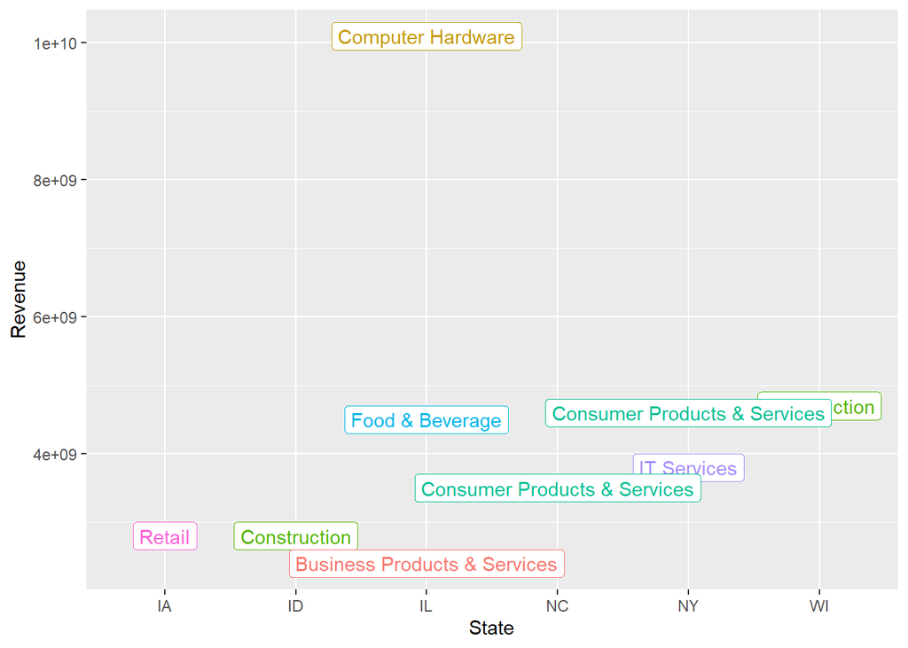

```r
#Plot to show by State, industries with the highest revenue where employees > 1000 from Sample of 50
ggplot(filter(sample, Employees > 1000),aes(x = State, y = Revenue, color = Industry)) +
  geom_point() +
  geom_label(aes(label = Industry)) +
  labs(x = "State", y = "Revenue") +
   theme(legend.position = "none")
```

## Question 1

Create a graph that shows the distribution of companies in the dataset by State (ie how many are in each state). There are a lot of States, so consider which axis you should use. This visualization is ultimately going to be consumed on a ‘portrait’ oriented screen (ie taller than wide), which should further guide your layout choices.

## Answer 1

I used ggplot below to show a portrait graph by using coord_flip().Then using Theme_Tufte. Additionally then I tried to plot the numbers on the bar graph and adjusted to size 3 so I can show the numbers on the graph.

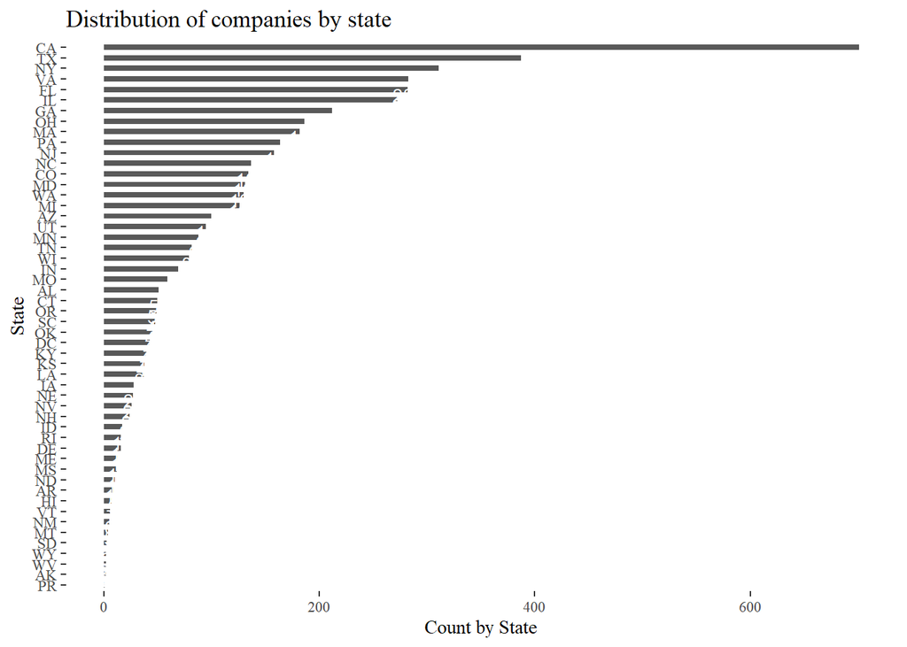

```r
# Answer Question 1 here

library(ggplot2)
library(tidyverse)
library(dplyr)
library(scales)
#graph1
inc %>% count(State) %>%
  ggplot(aes(x=reorder(State, n), y=n)) +
  geom_bar(stat = 'identity',width = 0.5, position = position_dodge(0.8)) +
  geom_text(aes(label=n), vjust=1.6, color="white", size=3.5) +
  coord_flip() +
  theme_tufte() +
  xlab("State") +
  ylab("Count by State") +
  ggtitle("Distribution of companies by state")
```

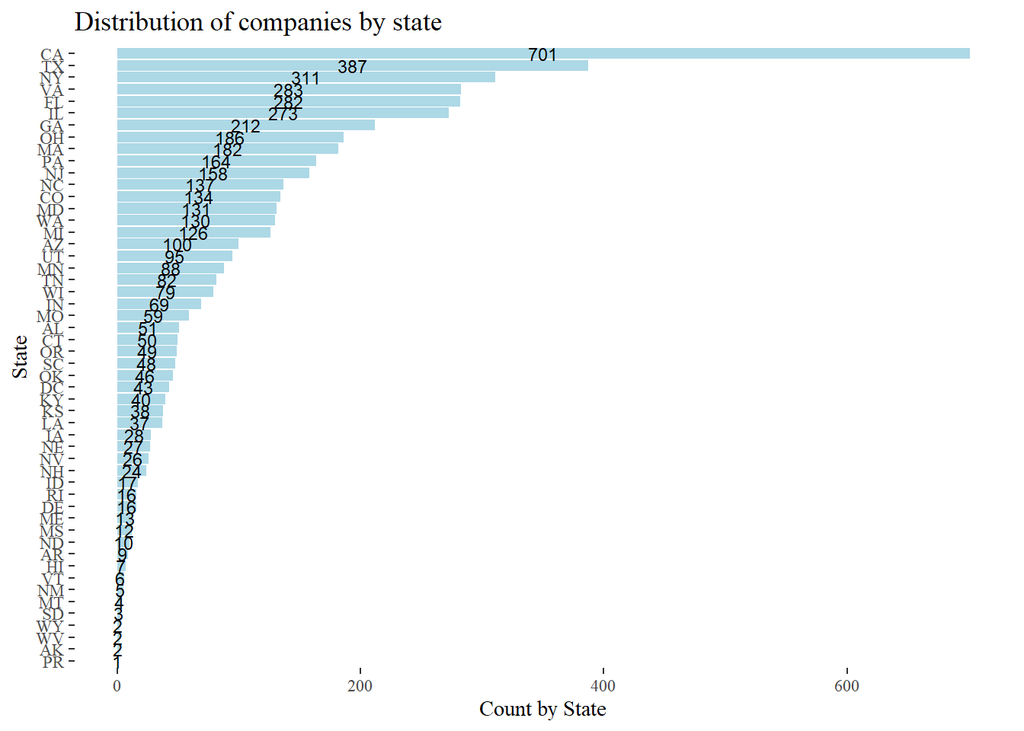

```r
#FINAL GRAPH FOR QUESTION1 : 2graph2 with numbers, and make the color a light blue with blank count of companies by state
inc %>% count(State) %>%
  ggplot(aes(x=reorder(State, n), y=n)) +
  geom_bar(stat = 'identity',fill = "light blue", position = "dodge") +
  geom_text(aes(label=n), position = position_stack(vjust= 0.5),
            colour = "black", size = 3) +

    coord_flip() +
  theme_tufte() +
  xlab("State") +
  ylab("Count by State") +
  ggtitle("Distribution of companies by state") + scale_color_brewer(palette = "Pastel1")
```

## Question 2

Lets dig in on the state with the 3rd most companies in the data set. Imagine you work for the state and are interested in how many people are employed by companies in different industries. Create a plot that shows the average and/or median employment by industry for companies in this state (only use cases with full data, use R’s `complete.cases()` function.) In addition to this, your graph should show how variable the ranges are, and you should deal with outliers.

## Answer 2 :

I tried to create a few plots to understand how to show the outlier data using axis transformation for log2 and log10. Also showed triangular on outlier data. User reorder method The “default” method treats its first argument as a categorical variable (Industry), and reorders its levels based on the values of a second variable (Employees), usually numeric

```r
# Answer Question 2 here

#1 Create a plot that shows the average and/or median employment by industry for companies in this state (only use cases with full data, use R's `complete.cases()` function.)

# Subset only NY records
NyState <- inc[ which(inc$State == 'NY'), ]
# Remove incomplete records
NyState  <- NyState[complete.cases(NyState ), ]
# show data
head(NyState )
```

```
##    Rank                      Name Growth_Rate  Revenue
## 26   26              BeenVerified       84.43 13700000
## 30   30                  Sailthru       73.22  8100000
## 37   37              YellowHammer       67.40 18000000
## 38   38                 Conductor       67.02  7100000
## 48   48 Cinium Financial Services       53.65  5900000
## 70   70                  33Across       44.99 27900000
##                        Industry Employees      City State
## 26 Consumer Products & Services        17  New York    NY
## 30      Advertising & Marketing        79  New York    NY
## 37      Advertising & Marketing        27  New York    NY
## 38      Advertising & Marketing        89  New York    NY
## 48           Financial Services        32 Rock Hill    NY
## 70      Advertising & Marketing        75  New York    NY
```

```r
#Find statistics
summary(NyState)
```

```
##       Rank          Name            Growth_Rate        Revenue
##  Min.   :  26   Length:311         Min.   : 0.350   Min.   :2.000e+06
##  1st Qu.:1186   Class :character   1st Qu.: 0.670   1st Qu.:4.300e+06
##  Median :2702   Mode  :character   Median : 1.310   Median :8.800e+06
##  Mean   :2612                      Mean   : 4.371   Mean   :5.872e+07
##  3rd Qu.:4005                      3rd Qu.: 3.580   3rd Qu.:2.570e+07
##  Max.   :4981                      Max.   :84.430   Max.   :4.600e+09
##    Industry           Employees           City              State
##  Length:311         Min.   :    1.0   Length:311         Length:311
##  Class :character   1st Qu.:   21.0   Class :character   Class :character
##  Mode  :character   Median :   45.0   Mode  :character   Mode  :character
##                     Mean   :  271.3
##                     3rd Qu.:  105.5
##                     Max.   :32000.0
```

```r
NyState %>% arrange(desc(Employees)) %>% head(50) %>% kable() %>% kable_styling()
```

| Rank | Name | Growth_Rate | Revenue | Industry | Employees | City | State |
| --- | --- | --- | --- | --- | --- | --- | --- |
| 4577 | Sutherland Global Services | 0.48 | 5.976e+08 | Business Products & Services | 32000 | Pittsford | NY |
| 4936 | Coty | 0.36 | 4.600e+09 | Consumer Products & Services | 10000 | New York | NY |
| 4716 | Westcon Group | 0.44 | 3.800e+09 | IT Services | 3000 | Tarrytown | NY |
| 3899 | Denihan Hospitality Group | 0.71 | 2.808e+08 | Travel & Hospitality | 2280 | New York | NY |
| 4363 | TransPerfect | 0.55 | 3.413e+08 | Business Products & Services | 2218 | New York | NY |
| 1499 | Sterling Infosystems | 2.66 | 2.149e+08 | Human Resources | 2081 | New York | NY |
| 4465 | OpenLink | 0.52 | 3.043e+08 | Software | 1271 | Uniondale | NY |
| 3136 | FSO Onsite Outsourcing | 1.05 | 5.530e+07 | Human Resources | 1134 | New York | NY |
| 2830 | ReSource Pro | 1.22 | 2.430e+07 | Business Products & Services | 1124 | New York | NY |
| 2995 | Pride Technologies | 1.13 | 2.310e+08 | Human Resources | 1000 | New York | NY |
| 3387 | Mitchell/Martin | 0.92 | 1.453e+08 | IT Services | 1000 | New York | NY |
| 4747 | TravelClick | 0.43 | 2.571e+08 | Travel & Hospitality | 906 | New York | NY |
| 2964 | DataArt | 1.14 | 3.070e+07 | Software | 800 | New York | NY |
| 4913 | Jackson Lewis | 0.37 | 3.520e+08 | Business Products & Services | 690 | White Plains | NY |
| 4646 | Mimeo.com | 0.46 | 8.770e+07 | Business Products & Services | 632 | New York | NY |
| 4153 | Everyday Health | 0.62 | 1.464e+08 | Media | 602 | New York | NY |
| 4003 | Ovation Travel Group | 0.67 | 5.860e+07 | Travel & Hospitality | 509 | New York | NY |
| 1640 | BlueWolf | 2.38 | 9.040e+07 | IT Services | 500 | New York | NY |
| 2971 | ConServe | 1.14 | 5.270e+07 | Financial Services | 483 | Fairport | NY |
| 4727 | Arrow Security | 0.44 | 1.400e+07 | Security | 450 | New York | NY |
| 3584 | Infusion | 0.84 | 6.790e+07 | IT Services | 432 | New York | NY |
| 4535 | Capital Access Network | 0.49 | 1.516e+08 | Financial Services | 425 | New York | NY |
| 4224 | Fragomen | 0.60 | 3.465e+08 | Business Products & Services | 404 | New York | NY |
| 3500 | Magnolia Bakery | 0.88 | 2.360e+07 | Food & Beverage | 383 | New York | NY |
| 1069 | Systems Made Simple | 3.94 | 1.671e+08 | IT Services | 382 | Syracuse | NY |
| 4039 | Empire Office | 0.66 | 3.496e+08 | Business Products & Services | 345 | New York | NY |
| 3704 | Infinity Consulting Solutions | 0.79 | 3.570e+07 | Human Resources | 325 | New York | NY |
| 3021 | Linium | 1.11 | 4.590e+07 | IT Services | 322 | New York | NY |
| 2218 | Globo Mobile | 1.67 | 4.500e+06 | Software | 320 | New York | NY |
| 2896 | Telx | 1.18 | 2.143e+08 | Telecommunications | 316 | New York | NY |
| 4820 | Aluf Plastics | 0.40 | 1.029e+08 | Manufacturing | 307 | Orangeburg | NY |
| 2436 | Shinetech Software | 1.48 | 1.200e+07 | IT Services | 300 | New York | NY |
| 3871 | eTransMedia Technology | 0.72 | 2.590e+07 | Health | 298 | Troy | NY |
| 4981 | SmartSource Computer & Audio Visual Rentals | 0.35 | 5.730e+07 | Business Products & Services | 296 | Hauppauge | NY |
| 1190 | Usablenet | 3.52 | 5.900e+07 | IT Services | 295 | New York | NY |
| 2556 | Precision Pipeline Solutions | 1.39 | 3.120e+07 | Energy | 294 | New Windsor | NY |
| 4944 | McElroy Deutsch | 0.36 | 1.165e+08 | Business Products & Services | 288 | New York | NY |
| 4732 | Mycroft | 0.43 | 2.640e+07 | IT Services | 275 | New York | NY |
| 4552 | Paradysz | 0.49 | 4.100e+07 | Advertising & Marketing | 270 | New York | NY |
| 4738 | McMurry/TMG | 0.43 | 9.140e+07 | Advertising & Marketing | 269 | New York City | NY |
| 3009 | 5Linx Enterprises | 1.12 | 1.036e+08 | Telecommunications | 268 | Rochester | NY |
| 1565 | Droga5 | 2.54 | 6.730e+07 | Advertising & Marketing | 250 | New York | NY |
| 2997 | Fibertech Networks | 1.13 | 1.423e+08 | Telecommunications | 250 | ROCHESTER | NY |
| 3661 | Environmental Products & Services of Vermont | 0.81 | 4.510e+07 | Environmental Services | 250 | Syracuse | NY |
| 1895 | nfrastructure | 2.00 | 5.320e+07 | IT Services | 237 | Clifton Park | NY |
| 1371 | Impelsys | 2.94 | 1.290e+07 | Software | 220 | New York | NY |
| 3054 | DDS Companies | 1.09 | 5.250e+07 | Construction | 219 | Rochester | NY |
| 275 | Technical Solutions | 15.85 | 1.630e+07 | Telecommunications | 213 | Walden | NY |
| 3262 | Sriven Systems | 0.98 | 2.530e+07 | IT Services | 210 | Melville | NY |
| 890 | Payoneer | 5.00 | 4.040e+07 | Financial Services | 207 | New YOrk | NY |

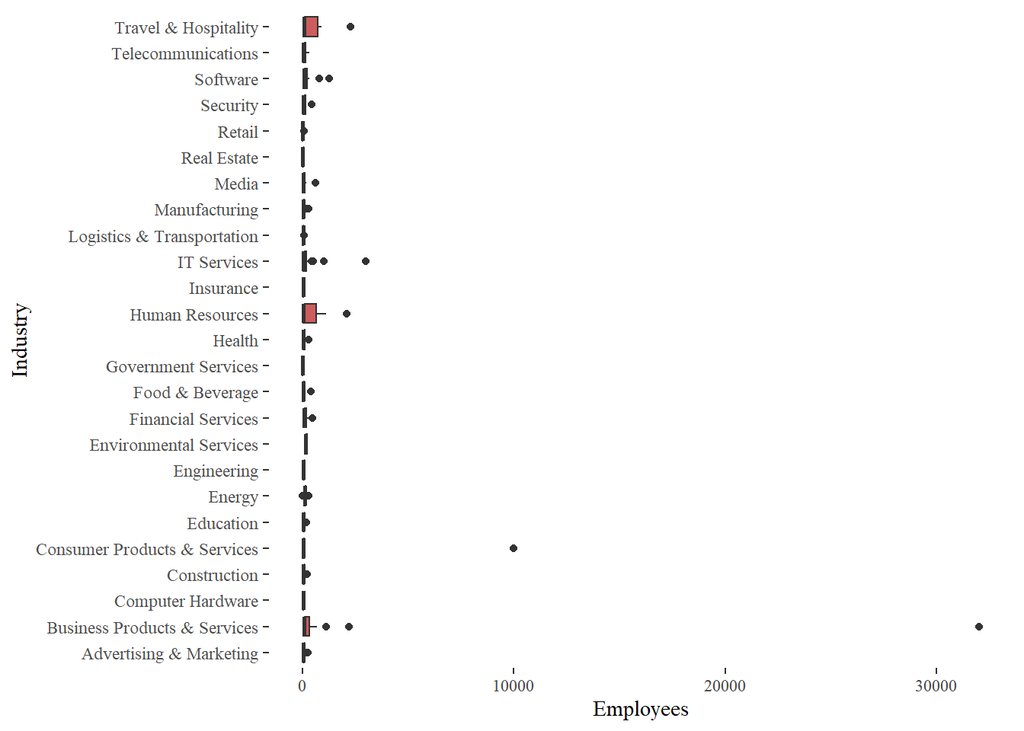

```r
#quick graph of NY state
ggplot(NyState, aes(x = Industry, y = Employees)) +
  geom_boxplot(fill = "indianred") +
  labs(x = "Industry", y = "Employees") +
   theme_tufte() + coord_flip()
```

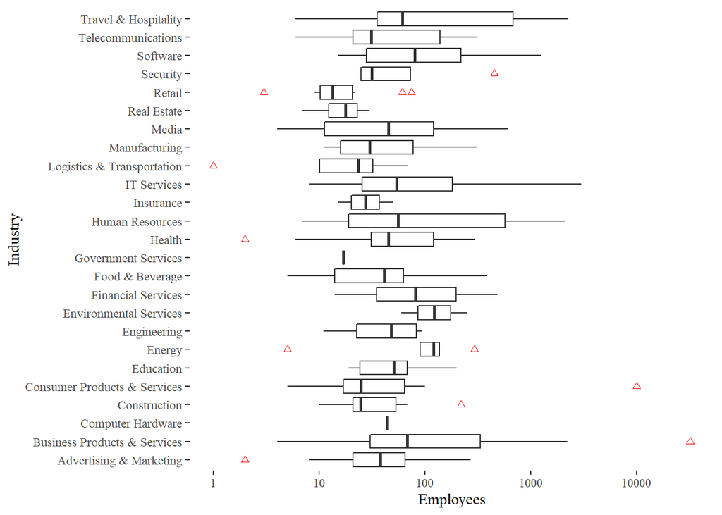

```r
# Graph to show boxplot with  log10 transformation.
ggplot(NyState, aes(x = Industry, y = Employees)) +
  geom_boxplot(outlier.colour = "Red",
               outlier.shape = 2) + theme_tufte() + coord_flip()+

 scale_y_continuous(trans = "log10")
```

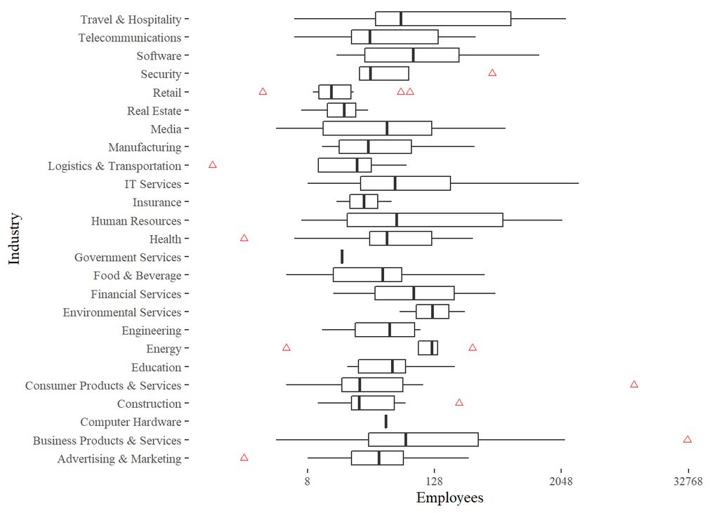

```r
#to show boxplot with  log2 transformation.
ggplot(NyState, aes(x = Industry, y = Employees)) +
  geom_boxplot(outlier.colour = "Red",
               outlier.shape = 2) + theme_tufte() + coord_flip() +
scale_y_continuous(trans = "log2")
```

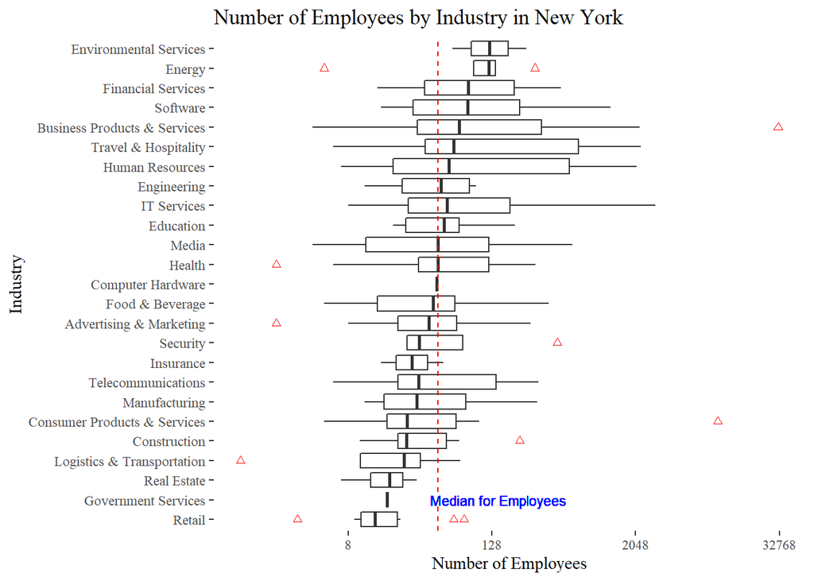

```r
#FINAL GRAPH FOR QUESTION2 : Graph to show boxplot with  log2 transformation. Use re-order. Shows Business Products and Services with max outlier
ggplot(NyState, aes(reorder(Industry, Employees, FUN = median), Employees)) +
  geom_boxplot(outlier.colour = "Red",
               outlier.shape = 2) +
 scale_y_continuous(trans = "log2", limits = c(min(NyState$Employees), max(NyState$Employees))) +
  coord_flip() +
  geom_hline(yintercept = median(NyState$Employees),
             color="Red",
             linetype="dashed") +
  geom_text(aes(x=2,
            label="Median for Employees", y = median(NyState$Employees)+100 ),
            size = 3,
            colour="blue") +

  xlab("Industry") +
  ylab("Number of Employees") +
  theme_tufte() +
  ggtitle("Number of Employees by Industry in New York")
```

## Question 3

Now imagine you work for an investor and want to see which industries generate the most revenue per employee. Create a chart that makes this information clear. Once again, the distribution per industry should be shown.

## Answer 3 :

```r
inc_nonmissing  <- inc[complete.cases(inc), ]
revemployee <- group_by(inc_nonmissing, Industry) %>% summarise(sum(Revenue),sum(Employees), revperemp = sum(Revenue) / sum(Employees))


revemployee %>% arrange(desc(revperemp)) %>% head(50) %>% kable() %>% kable_styling()
```

| Industry | sum(Revenue) | sum(Employees) | revperemp |
| --- | --- | --- | --- |
| Computer Hardware | 11885700000 | 9714 | 1223563.93 |
| Energy | 13771600000 | 26437 | 520921.44 |
| Construction | 13174300000 | 29099 | 452740.64 |
| Logistics & Transportation | 14837800000 | 39994 | 371000.65 |
| Consumer Products & Services | 14956400000 | 45464 | 328972.37 |
| Insurance | 2337900000 | 7339 | 318558.39 |
| Manufacturing | 12603600000 | 43942 | 286823.54 |
| Retail | 10257400000 | 37068 | 276718.46 |
| Financial Services | 13150900000 | 47693 | 275740.67 |
| Environmental Services | 2638800000 | 10155 | 259852.29 |
| Telecommunications | 7287900000 | 30842 | 236297.91 |
| Government Services | 6009100000 | 26185 | 229486.35 |
| Business Products & Services | 26345900000 | 117357 | 224493.64 |
| Health | 17860100000 | 82430 | 216669.90 |
| IT Services | 20525000000 | 102788 | 199682.84 |
| Advertising & Marketing | 7785000000 | 39731 | 195942.71 |
| Food & Beverage | 12812500000 | 65911 | 194390.92 |
| Media | 1742400000 | 9532 | 182794.80 |
| Software | 8134600000 | 51262 | 158686.75 |
| Real Estate | 2956800000 | 18893 | 156502.41 |
| Education | 1139300000 | 7685 | 148249.84 |
| Travel & Hospitality | 2931600000 | 23035 | 127267.20 |
| Engineering | 2532500000 | 20435 | 123929.53 |
| Security | 3812800000 | 41059 | 92861.49 |
| Human Resources | 9246100000 | 226980 | 40735.31 |

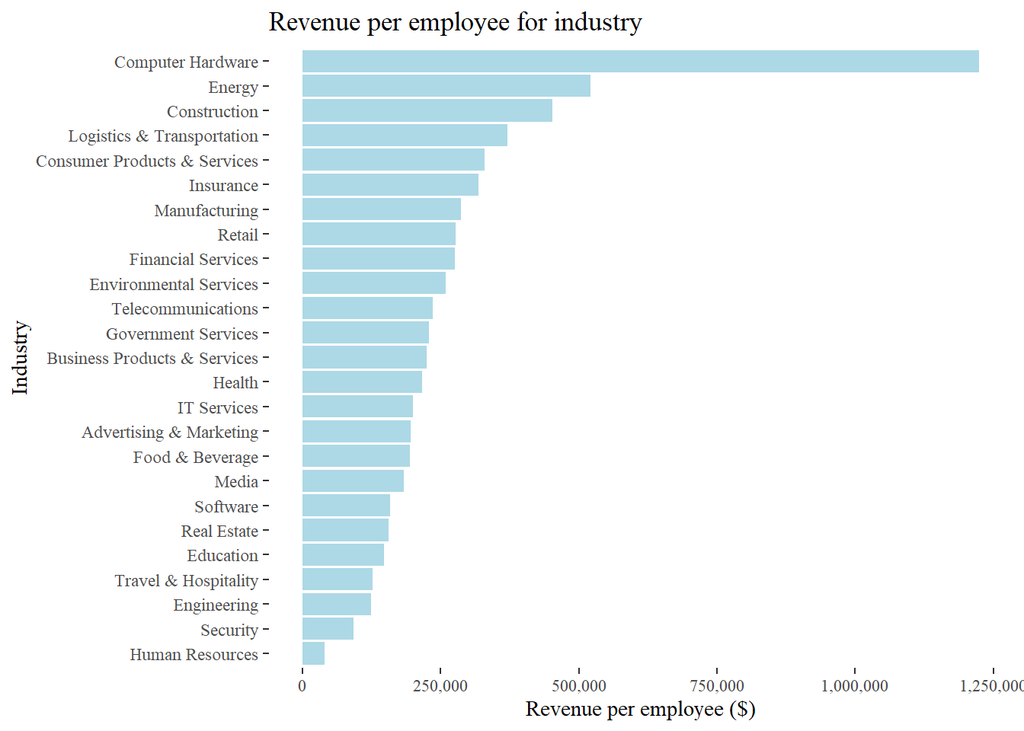

```r
ggplot(revemployee, aes(x=reorder(Industry, revperemp), y=revperemp)) +
  geom_bar(stat = 'Identity',fill = "light blue", position = "dodge") +
   coord_flip() +
  xlab("Industry") +
  ylab("Revenue per employee ($)") +
  ggtitle("Revenue per employee for industry") +
  scale_y_continuous(labels = scales::comma)+
  theme_tufte()
```